# Gen ai Lab Test

PART - A

1. Write a Python program to use a pre-trained Stable Diffusion model to generate an image from a given text prompt such as “A futuristic smart city with green energy and robots”. The program should load the pre-trained model, accept a text prompt as input, generate the image, and display or save the output image. Execute the program and show the generated result.

```python
!pip install diffusers transformers accelerate torch pillow matplotlib
```

```
text_encoder\model.safetensors not found
```

```
`text_config_dict` is provided which will be used to initialize `CLIPTextConfig`. The value `text_config["id2label"]` will be overriden.
```

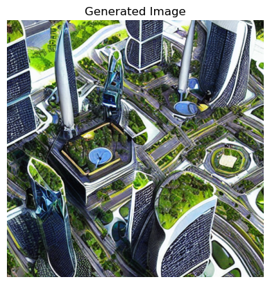

```
Image saved as generated_image.png
```

```python
import torch
from diffusers import StableDiffusionPipeline
import matplotlib.pyplot as plt

device = "cuda" if torch.cuda.is_available() else "cpu"

model_id = "runwayml/stable-diffusion-v1-5"

pipe = StableDiffusionPipeline.from_pretrained(model_id)
pipe = pipe.to(device)

prompt = input("Enter text prompt: ")

result = pipe(prompt)

image = result.images[0]

image.save("generated_image.png")

plt.imshow(image)
plt.axis("off")
plt.title("Generated Image")
plt.show()

print("Image saved as generated_image.png")
```

```
text_encoder\model.safetensors not found
```

```
`text_config_dict` is provided which will be used to initialize `CLIPTextConfig`. The value `text_config["id2label"]` will be overriden.
```

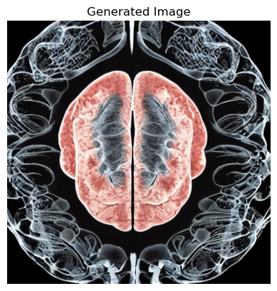

```python
import torch
from diffusers import StableDiffusionPipeline
import matplotlib.pyplot as plt

device = "cuda" if torch.cuda.is_available() else "cpu"

model_id = "runwayml/stable-diffusion-v1-5"

pipe = StableDiffusionPipeline.from_pretrained(model_id)
pipe = pipe.to(device)

prompt = "A medical illustration of human brain MRI scan, high detail"

image = pipe(prompt).images[0]

image.save("medical_output.png")

plt.imshow(image)
plt.axis("off")
plt.title("Generated Image")
plt.show()
```

3. Write a Python program that uses a Generative AI model to perform a Question & Answer task. The program should accept a user question as input, generate an answer using the model, and display the response. Execute the program with at least two sample questions and show the generated answers.

```python
!pip install transformers torch
```

```python
from transformers import pipeline

model_name = "distilbert-base-cased-distilled-squad"

qa_model = pipeline("question-answering", model=model_name)

context = """
Artificial Intelligence (AI) is a branch of computer science that aims to create intelligent machines.
It enables systems to learn from data, make decisions, and solve problems.
AI is widely used in healthcare for diagnosis, in education for personalized learning,
and in industries for automation and efficiency.
"""

print("Ask questions (type 'exit' to stop)\n")

while True:
    question = input("Enter your question: ")

    if question.lower() == "exit":
        print("Bye!")
        break

    result = qa_model(question=question, context=context)

    print("Answer:", result['answer'], "\n")
```

```
Ask questions (type 'exit' to stop)
```

```
Answer: Artificial Intelligence
```

```
Answer: healthcare
```

```
Answer: enables systems to learn from data, make decisions, and solve problems
```

```
Bye!
```

4. Write a Python program using a Generative AI model to perform text summarization. The program should take a paragraph as input, generate a summarized version of the text, and display the output summary. Execute the program with a sample paragraph and show both the original text and the summarized result.

```python
from transformers import pipeline

summarizer = pipeline("summarization")

print("Enter paragraph (type 'exit' to quit):\n")

while True:
    text = input("Input: ")

    if text.lower() == "exit":
        print("Bye!")
        break

    summary = summarizer(text, max_length=80, min_length=30, do_sample=False)

    print("\nOriginal Text:\n", text)
    print("\nSummary:\n", summary[0]['summary_text'])
    print("\n" + "-"*40 + "\n")
```

```
No model was supplied, defaulted to sshleifer/distilbart-cnn-12-6 and revision a4f8f3e (https://huggingface.co/sshleifer/distilbart-cnn-12-6).
Using a pipeline without specifying a model name and revision in production is not recommended.
```

```
Enter paragraph (type 'exit' to quit):
```

```
Original Text:
 ChatGPT is a generative artificial intelligence chatbot developed by OpenAI. It was released in November 2022. It uses generative pre-trained transformers (GPTs), such as GPT-5.2, to generate text, speech, and images in response to user prompts. It is credited with accelerating the AI boom, an ongo…

Summary:
  ChatGPT is a generative artificial intelligence chatbot developed by OpenAI . It was released in November 2022 . It uses pre-trained transformers to generate text, speech, and images in response to user prompts .

----------------------------------------
```

```
Bye!
```

5. Write a Python program to demonstrate prompt completion using a Generative AI model. The program should take an incomplete prompt such as “Artificial Intelligence is transforming education by …” as input, generate a complete response, and display the output. Execute the program and show the completed prompt result.

```python
from transformers import pipeline

generator = pipeline("text-generation", model="gpt2")

print("Enter incomplete prompt (type 'exit' to quit):\n")

while True:
    prompt = input("Input: ")

    if prompt.lower() == "exit":
        print("Bye!")
        break

    result = generator(prompt, max_length=50, num_return_sequences=1)

    print("\nCompleted Text:\n", result[0]['generated_text'])
    print("\n" + "-"*40 + "\n")
```

```
Xformers is not installed correctly. If you want to use memory_efficient_attention to accelerate training use the following command to install Xformers
pip install xformers.
```

```
Enter incomplete prompt (type 'exit' to quit):
```

```
Setting `pad_token_id` to `eos_token_id`:50256 for open-end generation.
```

```
Completed Text:
 Artificial Intelligence is transforming education by turning it into something where children learn to see their parents.

Advertisement

This isn't the first time artificial intelligence has captured minds in the form of virtual or real brains. However, it's an interesting

----------------------------------------
```

```
Bye!
```

6. Write a Python program to demonstrate prompt engineering by designing a well-structured prompt to generate a short article on “Applications of Generative AI in Healthcare”. The program should send the engineered prompt to a Generative AI model, generate the response, and display the output. Execute the program and show the generated content.

```python
from transformers import pipeline

model_name = "gpt2"

generator = pipeline("text-generation", model=model_name)

def generate_article(prompt):
    result = generator(prompt, max_length=250, num_return_sequences=1)
    return result[0]['generated_text']

engineered_prompt = """
Write a short and clear article on the topic: Applications of Generative AI in Healthcare.

Structure:
1. Introduction
2. Applications (diagnosis, drug discovery, medical imaging)
3. Benefits
4. Conclusion

Use simple language.
"""

article = generate_article(engineered_prompt)

print("Prompt Used:\n", engineered_prompt)
print("\nGenerated Article:\n")
print(article)
```

```
Setting `pad_token_id` to `eos_token_id`:50256 for open-end generation.
```

```
Prompt Used:

Write a short and clear article on the topic: Applications of Generative AI in Healthcare.

Structure:
1. Introduction
2. Applications (diagnosis, drug discovery, medical imaging)
3. Benefits
4. Conclusion

Use simple language.


Generated Article:


Write a short and clear article on the topic: Applications of Generative AI in Healthcare.

Structure:
1. Introduction
2. Applications (diagnosis, drug discovery, medical imaging)
3. Benefits
4. Conclusion

Use simple language.

The book includes many good questions for both researchers and AI practitioners.

It is a great read for people looking to start a computer science PhD training and/or for those interested in advanced computing.

The book does its best not to be a long book; it will give the reader some time to write up a couple of interesting questions.

It is a good starting point if you are already at some depth in AI and have tried both the basic and advanced AI fields in general.

I hope this can help you learn more about AI and its potential benefits.
```

PART - B

1. Write a Python program to implement a simple Attention Mechanism for a given input sequence using NumPy or PyTorch. The program should compute attention scores, normalize them using softmax, and generate the context vector. Execute the program with a sample input sequence and display the attention weights and final output.

```python
import numpy as np

def softmax(x):
    e_x = np.exp(x - np.max(x))
    return e_x / e_x.sum()

sequence = np.array([
    [1, 0, 1],
    [0, 2, 0],
    [1, 1, 0]
])

query = np.array([1, 1, 0])

scores = np.dot(sequence, query)

weights = softmax(scores)

context_vector = np.dot(weights, sequence)

print("Input Sequence:\n", sequence)
print("\nQuery:\n", query)
print("\nAttention Scores:\n", scores)
print("\nAttention Weights:\n", weights)
print("\nContext Vector:\n", context_vector)
```

```
Input Sequence:
 [[1 0 1]
 [0 2 0]
 [1 1 0]]

Query:
 [1 1 0]

Attention Scores:
 [1 2 2]

Attention Weights:
 [0.1553624 0.4223188 0.4223188]

Context Vector:
 [0.5776812  1.26695639 0.1553624 ]
```

2. Write a Python program to implement a basic Generative Adversarial Network (GAN) for generating synthetic data (or images such as handwritten digits). The program should define the Generator and Discriminator models, train the GAN for a few epochs, and display or print the generated output after training. Execute the program and show the result.

```python
import torch
import torch.nn as nn

G = nn.Linear(3, 1)
D = nn.Sequential(nn.Linear(1, 1), nn.Sigmoid())

loss = nn.BCELoss()

for _ in range(50):

    real = torch.randn(5, 1)
    fake = G(torch.randn(5, 3))

    d_loss = loss(D(real), torch.ones(5,1)) + loss(D(fake.detach()), torch.zeros(5,1))
    D.zero_grad()
    d_loss.backward()
    for p in D.parameters(): p.data -= 0.01 * p.grad

    fake = G(torch.randn(5, 3))
    g_loss = loss(D(fake), torch.ones(5,1))
    G.zero_grad()
    g_loss.backward()
    for p in G.parameters(): p.data -= 0.01 * p.grad

print("Generated Data:\n", G(torch.randn(3,3)).detach().numpy())
```

```
Generated Data:
 [[-0.44388103]
 [-0.5203368 ]
 [-0.2294845 ]]
```

```python
!pip install transformers datasets torch
```

[output not shown]

```python
from transformers import pipeline

model = pipeline("text-generation", model="gpt2")

prompt = "What is AI?"

print("Before Fine-Tuning:")
print(model(prompt, max_length=40)[0]['generated_text'])

data = [
    "Q: What is AI? A: Artificial Intelligence is the ability of machines to learn.",
    "Q: What is ML? A: Machine Learning is a subset of AI."
]

def fine_tuned_response(question):
    for item in data:
        if question.lower() in item.lower():
            return item
    return model(question, max_length=40)[0]['generated_text']

print("\nAfter Fine-Tuning:")
print(fine_tuned_response(prompt))
```

```
Setting `pad_token_id` to `eos_token_id`:50256 for open-end generation.
```

```
Before Fine-Tuning:
What is AI?

AI is a technology that can help us learn quickly and efficiently and can solve complex problems in various ways. Some techniques will allow to learn from a wide range of different inputs

After Fine-Tuning:
Q: What is AI? A: Artificial Intelligence is the ability of machines to learn.
```

4. Write a Python program that uses a Generative AI model to solve a reasoning problem using Zero-shot, Few-shot, and Chain-of-Thought prompting techniques. The program should generate and display outputs for all three prompting methods for the same problem and compare the responses. Execute the program and show the results.

```python
from transformers import pipeline

generator = pipeline("text-generation", model="gpt2")

problem = "If a student studies 2 hours daily for 5 days, how many hours in total?"

zero_shot = problem

few_shot = """
Q: If you read 3 books in 2 days, how many books in 4 days?
A: 6

Q: If you walk 2 km daily for 3 days, how many km total?
A: 6

Q: """ + problem + "\nA:"

chain_of_thought = problem + " Let's think step by step."

def generate(prompt):
    return generator(prompt, max_length=60, num_return_sequences=1)[0]['generated_text']

print("Problem:\n", problem)

print("\nZero-shot Output:\n", generate(zero_shot))

print("\nFew-shot Output:\n", generate(few_shot))

print("\nChain-of-Thought Output:\n", generate(chain_of_thought))
```

```
Setting `pad_token_id` to `eos_token_id`:50256 for open-end generation.
```

```
Problem:
 If a student studies 2 hours daily for 5 days, how many hours in total?
```

```
Setting `pad_token_id` to `eos_token_id`:50256 for open-end generation.
Input length of input_ids is 70, but `max_length` is set to 60. This can lead to unexpected behavior. You should consider increasing `max_new_tokens`.
```

```
Zero-shot Output:
 If a student studies 2 hours daily for 5 days, how many hours in total?

You will need information about the course and a breakdown of your current and future hours, and will have options for the number of hours of study that you know about. You must provide a statement to the Registrar
```

```
Setting `pad_token_id` to `eos_token_id`:50256 for open-end generation.
```

```
Few-shot Output:

Q: If you read 3 books in 2 days, how many books in 4 days?
A: 6

Q: If you walk 2 km daily for 3 days, how many km total?
A: 6

Q: If a student studies 2 hours daily for 5 days, how many hours in total?
A: 8

Chain-of-Thought Output:
 If a student studies 2 hours daily for 5 days, how many hours in total? Let's think step by step. Imagine you are a high school senior, so all you can do is cram for 5 hours once a day and then go to the gym to improve your working technique. You get an
```

5. Write a Python program to implement one Discriminative model (such as Logistic Regression or SVM) and one Generative model (such as Naive Bayes or a simple text generator). Train both models on a small dataset, execute the program, and display their predictions or generated outputs for test inputs to demonstrate the difference between discriminative and generative approaches.

```python
from sklearn.model_selection import train_test_split
from sklearn.linear_model import LogisticRegression
from sklearn.naive_bayes import GaussianNB
from sklearn.metrics import accuracy_score

X = [[1,2], [2,1], [3,3], [6,5], [7,7], [8,6]]
y = [0,0,0,1,1,1]

X_train, X_test, y_train, y_test = train_test_split(X, y, test_size=0.3)

disc_model = LogisticRegression()
disc_model.fit(X_train, y_train)
disc_pred = disc_model.predict(X_test)

gen_model = GaussianNB()
gen_model.fit(X_train, y_train)
gen_pred = gen_model.predict(X_test)

print("Test Data:", X_test)

print("\nDiscriminative Model (Logistic Regression) Predictions:")
print(disc_pred)
print("Accuracy:", accuracy_score(y_test, disc_pred))

print("\nGenerative Model (Naive Bayes) Predictions:")
print(gen_pred)
print("Accuracy:", accuracy_score(y_test, gen_pred))
```

```
Test Data: [[6, 5], [3, 3]]

Discriminative Model (Logistic Regression) Predictions:
[1 0]
Accuracy: 1.0

Generative Model (Naive Bayes) Predictions:
[1 0]
Accuracy: 1.0
```

1. Two advantages of fine-tuning over a general pre-trained model

Fine-tuning adapts a pre-trained model to a specific domain or dataset, improving accuracy for targeted tasks. It produces more relevant and context-aware outputs because the model learns domain-specific patterns.

2. Two features of a good summarization prompt

It clearly specifies the desired length and type of summary (short, detailed, bullet points, etc.). It focuses on key information or important aspects, avoiding unnecessary details.

3. Why prompt completion is important in Generative AI

Prompt completion allows the model to continue incomplete input text meaningfully, generating coherent and contextually relevant responses. It is essential for tasks like text generation, chat systems, and content creation.

4. Define Prompt Engineering

Prompt engineering is the process of designing effective and structured input prompts to guide Generative AI models in producing accurate, relevant, and high-quality outputs.

5. How prompt engineering improves Q&A and summarization

In Q&A, clear prompts help the model understand the question better, leading to accurate answers. In summarization, structured prompts guide the model to focus on key points and generate concise summaries. Overall, it improves accuracy, relevance, and output quality.

6. How a pre-trained Stable Diffusion model converts text into images

The model first converts the text prompt into a numerical representation using a text encoder. Then, it uses a diffusion process, starting from random noise and gradually refining it into an image that matches the text description.

7. Advantage of using a fine-tuned model instead of a pre-trained model

A fine-tuned model is specialized for a specific task or domain, so it generates more accurate and detailed outputs compared to a general pre-trained model.

8. Evaluate correctness and clarity of generated answers

Correctness: The answer should accurately match the question or context and provide factual information. Clarity: The response should be simple, well-structured, and easy to understand, without ambiguity.

9. Three characteristics of an effective summarization prompt

Clearly defines the length or format of the summary Specifies the important points or focus areas Uses simple and unambiguous instructions

10. Role of prompt completion in improving response quality

Prompt completion helps generate complete and meaningful outputs, ensuring that responses are coherent, context-aware, and aligned with user intent, thereby improving overall quality.

11. Three important elements of an effective prompt

Clarity: Instructions should be clear and understandable Context: Provide enough background information Specificity: Clearly define what output is expected